# Спецификация к Лабораторной работе №6

# Поиск экстремума с двумя условиями.

# Нисходящая разработка.

# (Вариант 22)

## Абстракция А0

### 1. Постановка задачи.

#### Задание:

Написать программу обработки одномерного массива в соответствии с условием.

#### Условие:

Для заданного целочисленного массива $\{A_1, A_2, …, A_n\}$ определить

номер первого максимального значения среди элементов,

- меньших A1 и
- расположенных правее последнего элемента, кратного девяти.

### 2. Уточненная постановка задачи.

Дан одномерный целочисленный массив A из n элементов.

Обозначим индекс $k: (A_k \in A) \land (A_k \vdots 9) \land \neg (A_i \vdots 9), \forall i > k$.

Найти $\displaystyle{j: A_j = \max_i \{A_i: A_i < A_1, \forall i > k\} }$.

### 3. Пример с иллюстрацией.

```python
import numpy
import pylab
%matplotlib inline
pylab.style.use('seaborn-whitegrid')
```

```python
A1 = numpy.random.randint(-100, 100, size=50)
numpy.savetxt('A_Lab6_1.txt', A1, fmt='%5.0f')
A1
```

```
array([ 30, -40, -22,  68,  46,  12, -94, -14, -75,  87, -47,  83,  51,
        -9, -30,  19,  21,  -2, -35,  37,  71,  77,  62,  70, -46,  81,
       -65, -85, -79,  49,  82,  92,  53,  13, -48, -80,  26, -32,   3,
       -69,  16, -42,  51, -51, -53,  82,  17, -55,  -7,  30])
```

```python
A2 = numpy.random.randint(1, 3, size=10)
numpy.savetxt('A_Lab6_2.txt', A2, fmt='%5.0f')
A2
```

```
array([1, 2, 2, 1, 2, 2, 1, 1, 2, 2])
```

```python
len(numpy.where(A2 < A2[0])[0]), len(numpy.where(A2 % 9 == 0)[0])
```

```
(0, 0)
```

```python
A3 = numpy.random.randint(5, 10, size=50)
numpy.savetxt('A_Lab6_3.txt', A3, fmt='%5.0f')
A3
```

```
array([8, 8, 9, 7, 7, 8, 5, 8, 5, 9, 6, 7, 6, 5, 6, 6, 7, 9, 6, 7, 7, 6,
       7, 8, 7, 6, 5, 8, 9, 6, 6, 5, 5, 9, 8, 6, 8, 5, 5, 7, 9, 8, 9, 9,
       6, 6, 7, 8, 8, 7])
```

```python
A4 = numpy.random.randint(-10, 10, size=20)
numpy.savetxt('A_Lab6_4.txt', A4, fmt='%5.0f')
A4
```

```
array([ 4,  5,  7,  2,  8,  1,  5,  7,  7, -3,  7,  9,  3, -7,  4, -7, -7,
       -4, -4,  1])
```

```python
A5 = numpy.random.randint(-10, 0, size=20)
numpy.savetxt('A_Lab6_5.txt', A5, fmt='%5.0f')
A5
```

```
array([ -6,  -1,  -7,  -8,  -1,  -1,  -9,  -2,  -5,  -1,  -5, -10,  -5,
        -9,  -4,  -8,  -4, -10,  -7,  -2])
```

```python
# A_Lab6_1.txt, A_Lab6_2.txt, A_Lab6_3.txt, A_Lab6_4.txt, A_Lab6_5.txt
# Aj_Lab6_1.txt, Aj_Lab6_2.txt, Aj_Lab6_3.txt, Aj_Lab6_4.txt, Aj_Lab6_5.txt

print(20*' ' + 'Лаб.6\n' + 90*'=')

fin = str(input('Текстовый файл с элементами массива A: '))
fout = str(input('Текстовый файл с элементами массива A и индексом максимального значения: '))

with open(fin, 'r') as f:
    A = numpy.array([int(x) for x in f.readlines()])

print(90*'=' + '\n' + 'Массив A: \n')
print(A)

if (len(numpy.where(A % 9 == 0)[0]) == 0) or (len(numpy.where(A < A[0])[0]) == 0):
    print(90*'=' + '\n' + 'Нет таких элементов')
    j = 0
else:
    k = numpy.max(numpy.where(A % 9 == 0)) + 1
    if (k == len(A)) or (len(numpy.where(A[k:] < A[0])[0]) == 0):
        print(90*'=' + '\n' + 'Нет таких элементов')
        j = 0
    else:
        j = numpy.argwhere(A[k:] == max(A[k:][A[k:] < A[0]]))[0][0] + k + 1

        print(90*'=' + '\n' + 'Индекс максимального значения выбранных элементов массива A:', j)

with open(fout, 'w') as f:
    for i in range(len(A)):
        f.write("{}\n".format(A[i]))
    f.write("{}".format(j))
```

```
                    Лаб.6
==========================================================================================
Текстовый файл с элементами массива A: A_Lab6_1.txt
Текстовый файл с элементами массива A и индексом максимального значения: Aj_Lab6_1.txt
==========================================================================================
Массив A:

[ 30 -40 -22  68  46  12 -94 -14 -75  87 -47  83  51  -9 -30  19  21  -2
 -35  37  71  77  62  70 -46  81 -65 -85 -79  49  82  92  53  13 -48 -80
  26 -32   3 -69  16 -42  51 -51 -53  82  17 -55  -7  30]
==========================================================================================
Индекс максимального значения выбранных элементов массива A: 37
```

```python
# python only
print(20*' ' + 'Лаб.6\n' + 110*'=')

fin = str(input('Текстовый файл с элементами массива A: '))
fout = str(input('Текстовый файл с элементами массива A и индексом максимального значения: '))

with open(fin, 'r') as f:
    A = [int(x) for x in f.readlines()]

print(110*'=' + '\n' + 'Массив A: \n')
print(A)

j, k, MAX = 0, 0, -1000000
for i in range(len(A)):
    if A[i] % 9 == 0:
        k = i + 1
for i in range(k, len(A)):
    if (A[i] < A[0]):
        if (A[i] > MAX):
            MAX, j = A[i], i + 1
if j == 0:
    print(110*'=' + '\n' + 'Нет таких элементов')
else:
    print(110*'=' + '\n' + 'Индекс максимального значения выбранных элементов массива A:', j)

with open(fout, 'w') as f:
    for i in range(len(A)):
        f.write("{}\n".format(A[i]))
    f.write("{}".format(j))
```

```
                    Лаб.6
==============================================================================================================
Текстовый файл с элементами массива A: A_Lab6_1.txt
Текстовый файл с элементами массива A и индексом максимального значения: Aj_Lab6_1.txt
==============================================================================================================
Массив A:

[30, -40, -22, 68, 46, 12, -94, -14, -75, 87, -47, 83, 51, -9, -30, 19, 21, -2, -35, 37, 71, 77, 62, 70, -46, 81, -65, -85, -79, 49, 82, 92, 53, 13, -48, -80, 26, -32, 3, -69, 16, -42, 51, -51, -53, 82, 17, -55, -7, 30]
==============================================================================================================
Индекс максимального значения выбранных элементов массива A: 37
```

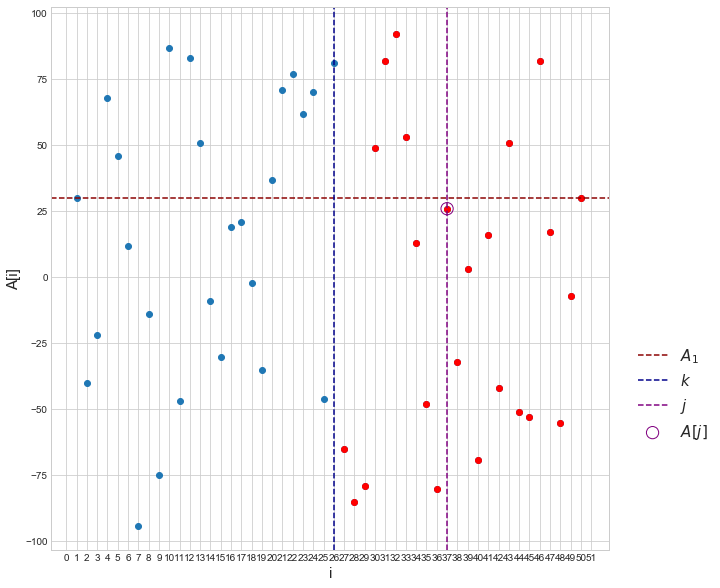

```python
pylab.figure(figsize=(10,10))
pylab.scatter(range(len(A)), A)
pylab.scatter(range(k, len(A)), A[k:], c='r')
pylab.scatter(j-1, A[j-1], s=150, label=r'$A[j]$',
              facecolors='none', edgecolors='purple')
pylab.axhline(A[0], c='darkred', ls='--', label=r'$A_1$')
pylab.axvline(k-1, c='darkblue', ls='--', label=r'$k$')
pylab.axvline(j-1, c='purple', ls='--', label=r'$j$')

pylab.xlabel('i', fontsize=15)
pylab.ylabel('A[i]', fontsize=15)
pylab.xticks(range(-1, len(A)+1), range(len(A)+2));
pylab.legend(fontsize=15, shadow=True, bbox_to_anchor=(1.2,0.4));
```

### 4. Таблица данных

| Класс | Имя | Описание (смысл, диапазон, точность) | Тип | Структура | Формат в/в |
| --- | --- | --- | --- | --- | --- |
| входные данные | fin | название текстового файла с элементами массива А | символ | строка | "+X.txt" |
| входные данные | fout | название текстового файла с элементами массива А | символ | строка | "+X.txt" |
| входные данные | A | вводимые из текстового файла числа | цел | одномерный массив | +XX (:5) |
| выходные данные | j | выводимый в текстовый файл индекс максимального значения среди выбранных элементов | цел | простая переменная | XX (:2) |
| промежуточные данные | k | индекс последнего кратного 9 элемента из $A$ | цел | простая переменная | --- |
| промежуточные данные | i | индекс текущего элемента, 1≤i≤50 | цел | простая переменная | --- |
| промежуточные данные | f | значение первого элемента массива | цел | простая переменная | --- |
| промежуточные данные | MAX | максимальное значение среди выбранных элементов | цел | простая переменная | --- |

*! в Delphi выход из цикла с 1 до 20 с шагом +1 происходит при значении 21, из цикла с 20 до 1 – при 0*

### 5. Входная форма

- обр 1.1 Текстовый файл с элементами массива A: $<fin>$
- обр 1.2 Текстовый файл с элементами массива A и индексом максимального значения: $<fout>$
- обр 2.1 Массив A:
- обр 2.2 $ < A[1] > < A[2] > … < A[n] > $

### 6. Выходная форма

- обр 3 Лаб. 6
- обр 4.1 Текстовый файл с элементами массива A: $<fin>$
- обр 4.2 Текстовый файл с элементами массива A и индексом максимального значения: $<fout>$
- обр 5.1 Массив A:
- обр 5.2 $ < A[1] > < A[2] > … < A[n] > $
- обр 6.1 Индекс максимального значения выбранных элементов массива A: $< j >$
- обр 6.2 Нет таких элементов

### 7. Аномалии

-

### 8. Функциональные тесты

| Исходные данные | - | - | Результаты | - | Тест |
| --- | --- | --- | --- | --- | --- |
| fin | fout | A | j | Сообщение | № |
| A_Lab6_1.txt | Aj_Lab6_1.txt | `[30 -40 -22 68 46 12 -94 -14 -75 87 -47 83 51 -9 -30 19 21 -2 -35 37 71 77 62 70 -46 81 -65 -85 -79 49 82 92 53 13 -48 -80 26 -32 3 -69 16 -42 51 -51 -53 82 17 -55 -7 30]` | `37` | - | 1 |
| - | - | - | - | - | - |
| A_Lab6_2.txt | Aj_Lab6_2.txt | `[1 2 2 1 2 2 1 1 2 2]` | `0` | `Нет таких элементов` | 2 |
| - | - | - | - | - | - |
| A_Lab6_3.txt | Aj_Lab6_3.txt | `[8 8 9 7 7 8 5 8 5 9 6 7 6 5 6 6 7 9 6 7 7 6 7 8 7 6 5 8 9 6 6 5 5 9 8 6 8 5 5 7 9 8 9 9 6 6 7 8 8 7]` | `47` | - | 3 |
| - | - | - | - | - | - |
| A_Lab6_4.txt | Aj_Lab6_4.txt | `[4 5 7 2 8 1 5 7 7 -3 7 9 3 -7 4 -7 -7 -4 -4 1]` | `13` | - | 4 |
| - | - | - | - | - | - |
| A_Lab6_5.txt | Aj_Lab6_5.txt | `[-6 -1 -7 -8 -1 -1 -9 -2 -5 -1 -5 -10 -5 -9 -4 -8 -4 -10 -7 -2]` | `19` | - | 5 |

| № теста | Входные данные | - | - | Ожидаемый результат | - | Смысл теста |
| --- | --- | --- | --- | --- | --- | --- |
| - | - | - | - | - | - | - |
| 1 | fin = 'A_Lab6_1.txt' | fout = 'Aj_Lab6_1.txt' | A = `[30 -40 -22 68 46 12 -94 -14 -75 87 -47 83 51 -9 -30 19 21 -2 -35 37 71 77 62 70 -46 81 -65 -85 -79 49 82 92 53 13 -48 -80 26 -32 3 -69 16 -42 51 -51 -53 82 17 -55 -7 30]` | j = `37` | - | Подтвердить правильность расчетов в случае широкого спектра положительных и отрицательных чисел |
| - | - | - | - | - | - | - |
| 2 | fin = 'A_Lab6_2.txt' | fout = 'Aj_Lab6_2.txt' | A = `[1 2 2 1 2 2 1 1 2 2]` | j = `0` | Сообщение = 'Нет таких элементов' | Протестировать простейший случай |
| - | - | - | - | - | - | - |
| 3 | fin = 'A_Lab6_3.txt' | fout = 'Aj_Lab6_3.txt' | A = `[8 8 9 7 7 8 5 8 5 9 6 7 6 5 6 6 7 9 6 7 7 6 7 8 7 6 5 8 9 6 6 5 5 9 8 6 8 5 5 7 9 8 9 9 6 6 7 8 8 7]` | j = `47` | - | Протестировать массив в узком диапазоне положительных чисел |
| - | - | - | - | - | - | - |
| 4 | fin = 'A_Lab6_4.txt' | fout = 'Aj_Lab6_4.txt' | A = `[4 5 7 2 8 1 5 7 7 -3 7 9 3 -7 4 -7 -7 -4 -4 1]` | j = `13` | - | Протестировать массив в узком диапазоне положительных и отрицательных чисел |
| - | - | - | - | - | - | - |
| 5 | fin = 'A_Lab6_5.txt' | fout = 'Aj_Lab6_5.txt' | A = `[-6 -1 -7 -8 -1 -1 -9 -2 -5 -1 -5 -10 -5 -9 -4 -8 -4 -10 -7 -2]` | j = `19` | - | Подтвердить правильность расчетов в случае отрицательных чисел |

| - | Результаты | № теста |
| --- | --- | --- |
| - | - | - |
| j | Максимальная вычислительная нагрузка = 50 (проверка делимости) + 24 (проверка меньше ли первого элемента) + 17 (поиск максимума) | 1 |
| - | Соответствует ожидаемым числовым значениям | - |
| j | 0 | 2 |
| - | Отсутствие элементов, соответствующих условиям | - |
| j | Максимальная вычислительная нагрузка = 50 (проверка делимости) + 6 (проверка меньше ли первого элемента) + 4 (поиск максимума) | 3 |
| - | Соответствует ожидаемым числовым значениям и легко подтверждается визуально | - |
| j | Максимальная вычислительная нагрузка = 20 (проверка делимости) + 8 (проверка меньше ли первого элемента) + 7 (поиск максимума) | 4 |
| - | Соответствует ожидаемым числовым значениям | - |
| j | Максимальная вычислительная нагрузка = 20 (проверка делимости) + 6 (проверка меньше ли первого элемента) + 3 (поиск максимума) | 5 |
| - | Соответствует ожидаемым числовым значениям | - |
| - | - | - |
| Сообщение | - | 1 |
| Сообщение | Нет таких элементов | 2 |
| Сообщение | - | 3 |
| Сообщение | - | 4 |
| Сообщение | - | 5 |

### 9. Метод

Отделим ввод-вывод от обработки данных и разделим задачу на три подзадачи:

1. *Подзадача А 0.1.* Запросить названия текстовых файлов ввода-вывода, считать из текстового файла ввода исходные данные (обр.1-2), затем вывести их на экран (обр.3-5) для визуального подтверждения.
2. *Подзадача А 0.2.* Решение поставленной задачи: на основе введенных исходных данных (`A`) определить номер первого максимального значения среди элементов,
   - меньших A1 и
   - расположенных правее последнего элемента, кратного девяти.
3. *Подзадача А 0.3.* Ввести полученные результаты (`j`) на экран (обр.6) и записать в файл вывода исходный массив и полученный результат.

Ввод-вывод тривиален и представляет собой чисто техническую задачу.

Для осуществления процесса ввода-вывода и обработки массива потребуются промежуточные переменные:

- `i` – индекс текущего элемента массива,
- `f` - значение первого элемента массива,
- `k` - индекс последнего кратного 9 элемента в массиве,
- `MAX` - максимальное значение среди выбранных согласно условиям элементов массива.

Их следует добавить в таблицу данных.

Алгоритм необходим только для обработка входных данных и расчета результата.

### 10. Алгоритм

[Sample diagrams](http://blockdiag.com/en/blockdiag/examples.html#sample-diagrams)

```python
%%file block_diagram

blockdiag {
    orientation = portrait;
    class start_end [shape = ellipse, fontsize = 15, color = lightskyblue];
    class input_out [shape = flowchart.input, fontsize = 15, width = 750, color = lightcyan];
    class main_box [shape = box, width = 500, height = 150, fontsize = 18];

    Начало ->
    "Вывод заголовка по обр.3 на экран" ->
    "Ввод имени файла по обр.1.1" -> "Ввод имени файла по обр.1.2" ->
    "Вывод пояснения по обр.2.1" -> "Ввод А из файла по обр.2.2" ->
    "Вывод имени файла по обр.4.1 на экран" -> "Вывод имени файла по обр.4.2 на экран" ->
    "Вывод пояснения по обр.5.1 на экран" -> "Вывод А на экран и в файл по обр.5.2" ->
    "Определение индекса \nмаксимального значения \nвыбранных элементов массива A \n(j)" ->
    "Вывод j или сообщения на экран и в файл по обр.6" ->
    Конец;

    Начало, Конец [class = "start_end"];
    "Ввод имени файла по обр.1.1", "Ввод имени файла по обр.1.2" [class = "input_out"];
    "Вывод пояснения по обр.2.1", "Ввод А из файла по обр.2.2" [class = "input_out"];
    "Вывод имени файла по обр.4.1 на экран", "Вывод имени файла по обр.4.2 на экран" [class = "input_out"];
    "Вывод пояснения по обр.5.1 на экран", "Вывод А на экран и в файл по обр.5.2" [class = "input_out"];
    "Вывод заголовка по обр.3 на экран", "Вывод j или сообщения на экран и в файл по обр.6" [class = "input_out"];
    "Определение индекса \nмаксимального значения \nвыбранных элементов массива A \n(j)" [class = "main_box"];

    "Вывод А на экран и в файл по обр.5.2" ->
    "Определение индекса \nмаксимального значения \nвыбранных элементов массива A \n(j)" [label = 'Вх. А', fontsize = 18];
    "Определение индекса \nмаксимального значения \nвыбранных элементов массива A \n(j)" ->
    "Вывод j или сообщения на экран и в файл по обр.6" [label = 'Вых. j', fontsize = 18];
}
```

```
Overwriting block_diagram
```

```python
!blockdiag block_diagram
```

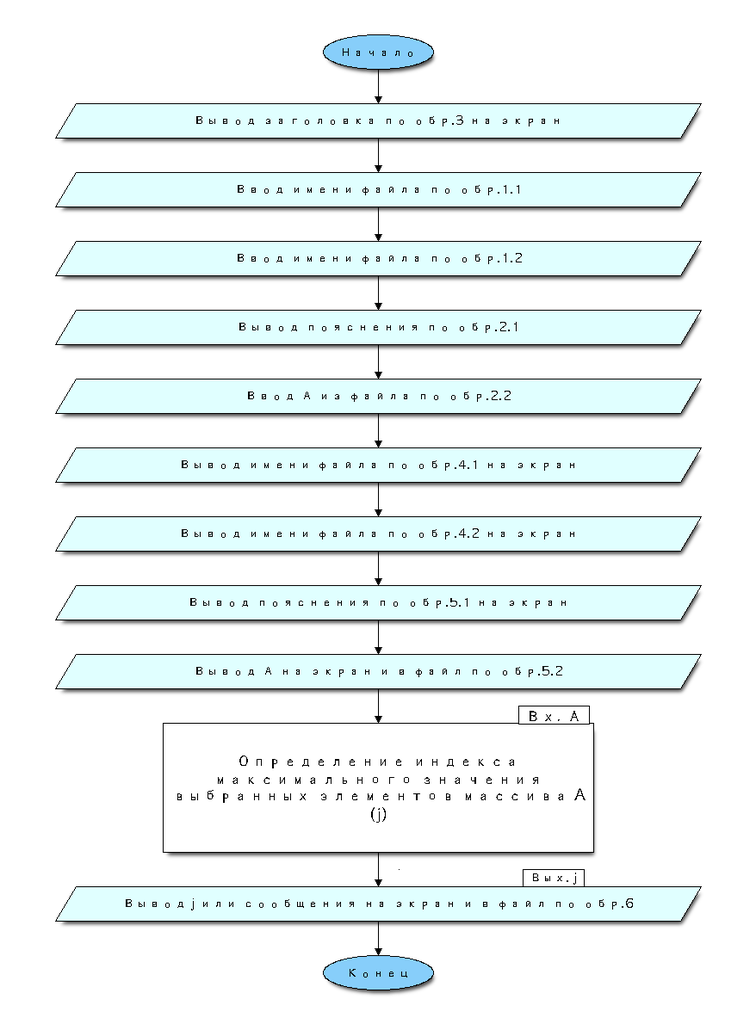

```python
from IPython.display import Image
Image("block_diagram.png")
```

### 11. Программа на *Delphi*.

**Диалоговый вариант {ввод названий файлов и данных из текстового файла, вывод на экран и в текстовый файл}**

Синтаксис:

[Pascal Tutorial](https://www.tutorialspoint.com/pascal/index.htm)

Проверить программу онлайн без установки программной среды:

[Compile and Execute Pascal Online](http://www.compileonline.com/compile_pascal_online.php)

```python
program Lab6; //сохранить как lab6.dpr (DPR – Delphi PRoject)
{$APPTYPE CONSOLE}
Uses Windows; // для русификации (сделать комментарием в онлайн-компиляторе!)

    var
        i, j, k, f: integer;
        MAX: integer;
        fin, fout: string;
        tfin, tfout: TextFile;
        A: array of integer;

    begin
        setConsoleCP(1251); // для ввода  русификация и (сделать строку комментарием в онлайн-компиляторе!)
        setConsoleOutputCP(1251); // для вывода (сделать строку комментарием в онлайн-компиляторе!)

        {A0.1, A0.3 - ввод-вывод входных данных}
        writeln('Лаб.6' :40); {вывод заголовка c переходом на следующую строку по обр.3}

        {ввод-вывод строковой переменной - имени файла с входными данными по обр.1.1, 4.1}
        writeln('Текстовый файл с элементами массива A:  ');
        readln(fin);
        writeln(fin);

        {ввод-вывод строковой переменной - имени файла с выходными данными по обр.1.2, 4.2}
        writeln('Текстовый файл с элементами массива A и индексом максимального значения: ');
        readln(fout);
        writeln(fout);

        {ввод-вывод исходного массивa A по обр.2.1, 2.2, 5.1, 5.2}
        writeln('Массив A: '); {вывод пояснения с переходом на следующую строку}

        AssignFile(tfin, fin); reset(tfin); {открыть файл для чтения}
        AssignFile(tfout, fout); rewrite(tfout); {открыть файл для записи}

        j := 0; k := 0; MAX := -10000;

        i := 1;

        while not eof(tfin) do

        begin
            SetLength(A,i);
            readln(tfin, A[i]); {ввод элемента и переход на следующую строку}
            writeln(A[i]:5); {вывод элемента и переход на следующую строку на экране}
            writeln(tfout, A[i]:5); {вывод элемента и переход на следующую строку в файле}
            if (i = 1) then f := A[i];

            k := 26; j := 37; MAX := 26; {заглушка для теста 1}
            // j :=0; {заглушка для теста 2}
            // k := 44; j := 47; MAX := 7; {заглушка для теста 3}
            // k := 12; j := 13; MAX := 3; {заглушка для теста 4}
            // k := 14; j := 19; MAX := -7; {заглушка для теста 5}

            i := i + 1;
        end;

        CloseFile(tfin); {закрыть файл для чтения}

        for i:=1 to 80 do
            write('='); {отделим визуально чертой и строкой введенные и выводимые значения}
        writeln;

        {вывод пояснения с переходом на следующую строку}
        if j = 0 then writeln('Нет таких элементов');
        writeln('Индекс максимального значения выбранных элементов массива A:', j:2);
        {вывод переменной и переход на следующую строку на экране по обр.6}
        writeln(tfout, j:2);
        {вывод переменной и переход на следующую строку в файле по обр.6}

        CloseFile(tfout); {закрыть файл для записи}

    end.
```

## Раскрытие абстракции А0.2

*Поскольку условие всей задачи совпадает (за исключением необходимости ввода-вывода) с условием выделенной подзадачи,*

*вместо полной спецификации с пунктами 1-11 выполнено просто дополнение к пунктам 9-11.*

### 9. Метод

Пусть

- $i$ – номер текущий точки,
- $A[i]$ – соответствующий элемент исходного массива A,
- $k$ - индекс последнего кратного 9 элемента из A,
- $f$ - значение первого элемента массива,
- $MAX$ - первое максимальное значение среди элементов,
  - меньших $f$ и
  - расположенных правее последнего элемента, кратного девяти.
- $j$ - номер этого первого максимального значения.

Присвоим переменным начальные значения: $MAX = -10000, j = 0, k = 0$.

Поиск индекса последнего кратного 9 элемента из A осуществляется с помощью цикла.

На каждом этапе определяется, делится элемент на 9 или нет.

Если делится, то значение индекса $k$ обновляется, а $MAX = -10000$ возвращается к исходному значению.

Для элементов с индексом $i: k < i < $ длины массива А, определяется

- индекс $j$-ого элемента, максимального в этом ряду, но меньше $f$.

Если в цикле удается найти новый элемент, больше предыдущего максимального значения, но меньше $f$,

то значения $j, MAX$ обновляются.

### 10. Алгоритм

```python
%%file block_diagram2

blockdiag {
    orientation = portrait;

    class yes [thick, label = "Да", color = blue, textcolor = blue];
    class no [thick, label = "Нет", color = red, textcolor = red];
    class start_end [shape = ellipse, fontsize = 18, color = lightskyblue];
    class input_out [shape = flowchart.input, fontsize = 18,
                     width = 400, color = lightcyan];
    class loop_in [shape = flowchart.loopin, fontsize = 18,
                   width = 300, color = lightsteelblue];
    class loop_out [shape = flowchart.loopout, fontsize = 18,
                    width = 300, color = lightsteelblue];
    class condition [shape = flowchart.condition, fontsize = 18,
                     width = 400, height = 100, color = lightsteelblue];
    class command_box [shape = roundedbox, fontsize = 18, width = 300];

    Начало -> "j :=0; k := 0; MAX := -10000;" -> "i := 1; +1; n" ->
    "i = 1" -> "f := A[i];" -> "A[i] MOD 9 = 0";

    "i = 1" ->  "A[i] MOD 9 = 0" ;

    "A[i] MOD 9 = 0"-> "k := i; MAX := -10000;" ->
    "(i > k) and (A[i] < f) and (MAX < A[i])" -> "j := i; MAX := A[i];" -> "i = n"

    "A[i] MOD 9 = 0"-> "(i > k) and (A[i] < f) and (MAX < A[i])";

    "(i > k) and (A[i] < f) and (MAX < A[i])" -> "i = n" -> Конец;

    Начало, Конец [class = "start_end"];
    "i := 1; +1; n" [class = "loop_in"];
    "i = n" [class = "loop_out"];
    "i = 1", "A[i] MOD 9 = 0", "(i > k) and (A[i] < f) and (MAX < A[i])" [class = "condition"];
    "j :=0; k := 0; MAX := -10000;", "j := i; MAX := A[i];"  [class = "command_box"];
    "f := A[i];", "k := i; MAX := -10000;" [class = "command_box"];

    "i = 1" -> "f := A[i];" [class = 'yes'];
    "i = 1" ->  "A[i] MOD 9 = 0" [class = 'no'];
    "A[i] MOD 9 = 0"-> "k := i; MAX := -10000;" [class = 'yes'];
    "A[i] MOD 9 = 0"-> "(i > k) and (A[i] < f) and (MAX < A[i])" [class = 'no'];
    "(i > k) and (A[i] < f) and (MAX < A[i])" -> "j := i; MAX := A[i];" [class = 'yes'];
    "(i > k) and (A[i] < f) and (MAX < A[i])" -> "i = n" [class = 'no'];

}
```

```
Overwriting block_diagram2
```

```python
!blockdiag block_diagram2
```

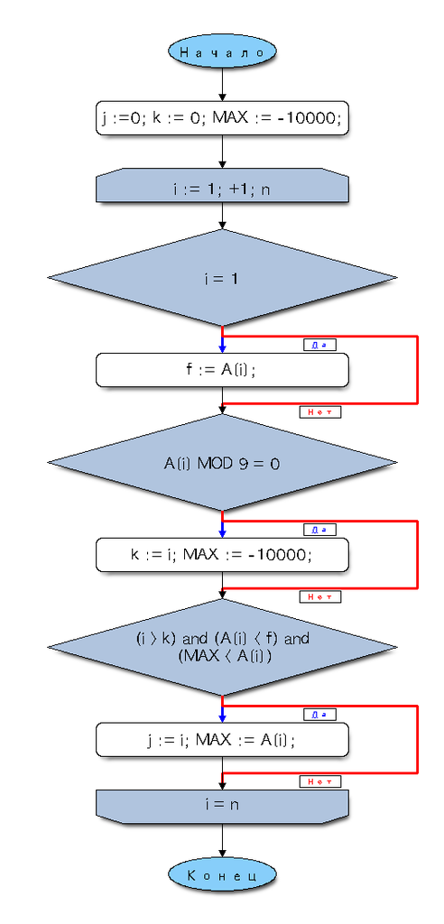

```python
Image("block_diagram2.png")
```

### 11. Программа на *Delphi*.

#### Программный код раскрытия абстракции.

```python
if (A[i] MOD 9 = 0) then
begin
    k := i; MAX := -10000;
end;

if (i > k) and (A[i] < f) and (MAX < A[i]) then
begin
    j := i; MAX := A[i];
end;
```

#### Вариант программы для чтения и записи текстовых файлов.

```python
program Lab6; //сохранить как lab6.dpr (DPR – Delphi PRoject)
{$APPTYPE CONSOLE}
Uses Windows; // для русификации (сделать комментарием в онлайн-компиляторе!)

    var
        i, j, k, f: integer;
        MAX: integer;
        fin, fout: string;
        tfin, tfout: TextFile;
        A: array of integer;

    begin
        setConsoleCP(1251); // для ввода  русификация и (сделать строку комментарием в онлайн-компиляторе!)
        setConsoleOutputCP(1251); // для вывода (сделать строку комментарием в онлайн-компиляторе!)

        {A0.1, A0.3 - ввод-вывод входных данных}
        writeln('Лаб.6' :40); {вывод заголовка c переходом на следующую строку по обр.3}

        {ввод-вывод строковой переменной - имени файла с входными данными по обр.1.1, 4.1}
        writeln('Текстовый файл с элементами массива A:  ');
        readln(fin);
        writeln(fin);

        {ввод-вывод строковой переменной - имени файла с выходными данными по обр.1.2, 4.2}
        writeln('Текстовый файл с элементами массива A и индексом максимального значения: ');
        readln(fout);
        writeln(fout);

        {ввод-вывод исходного массивa A по обр.2.1, 2.2, 5.1, 5.2}
        writeln('Массив A: '); {вывод пояснения с переходом на следующую строку}

        AssignFile(tfin, fin); reset(tfin); {открыть файл для чтения}
        AssignFile(tfout, fout); rewrite(tfout); {открыть файл для записи}

        j := 0; k := 0; MAX := -10000;

        i := 1;

        while not eof(tfin) do

        begin
            SetLength(A,i);
            readln(tfin, A[i]); {ввод элемента и переход на следующую строку}
            writeln(A[i]:5); {вывод элемента и переход на следующую строку на экране}
            writeln(tfout, A[i]:5); {вывод элемента и переход на следующую строку в файле}

            if (i = 1) then f := A[i];

            if (A[i] MOD 9 = 0) then
            begin
                k := i; MAX := -10000;
            end;

            if (i > k) and (A[i] < f) and (MAX < A[i]) then
            begin
                j := i; MAX := A[i];
            end;

            i := i + 1;
        end;

        CloseFile(tfin); {закрыть файл для чтения}

        for i:=1 to 80 do
            write('='); {отделим визуально чертой и строкой введенные и выводимые значения}
        writeln;

        {вывод пояснения с переходом на следующую строку}
        if j = 0 then writeln('Нет таких элементов');
        writeln('Индекс максимального значения выбранных элементов массива A:', j:2);
        {вывод переменной и переход на следующую строку на экране по обр.6}
        writeln(tfout, j:2);
        {вывод переменной и переход на следующую строку в файле по обр.6}

        CloseFile(tfout); {закрыть файл для записи}

    end.
```

#### Вариант программы с именами файлов, заданными в качестве параметров.

```python
program Lab6; //сохранить как lab6.dpr (DPR – Delphi PRoject)
{$APPTYPE CONSOLE}
Uses Windows; // для русификации (сделать комментарием в онлайн-компиляторе!)

    var
        i, j, k, f: integer;
        MAX: integer;
        tfin, tfout: TextFile;
        A: array of integer;

    begin
        setConsoleCP(1251); // для ввода  русификация и (сделать строку комментарием в онлайн-компиляторе!)
        setConsoleOutputCP(1251); // для вывода (сделать строку комментарием в онлайн-компиляторе!)

        if (ParamCount<2) then
        begin
        writeln('CritError: Не заданы параметры программы');
        readln: exit;
        end;

        {A0.1, A0.3 - ввод-вывод входных данных}
        writeln('Лаб.6' :40); {вывод заголовка c переходом на следующую строку по обр.3}

        {ввод-вывод исходного массивa A по обр.2.1, 2.2, 5.1, 5.2}
        writeln('Массив A: '); {вывод пояснения с переходом на следующую строку}

        AssignFile(tfin, ParamStr(1)); reset(tfin); {открыть файл для чтения}
        AssignFile(tfout, ParamStr(2)); rewrite(tfout); {открыть файл для записи}

        j := 0; k := 0; MAX := -10000;

        i := 1;

        while not eof(tfin) do

        begin
            SetLength(A,i);
            readln(tfin, A[i]); {ввод элемента и переход на следующую строку}
            writeln(A[i]:5); {вывод элемента и переход на следующую строку на экране}
            writeln(tfout, A[i]:5); {вывод элемента и переход на следующую строку в файле}

            if (i = 1) then f := A[i];

            if (A[i] MOD 9 = 0) then
            begin
                k := i; MAX := -10000;
            end;

            if (i > k) and (A[i] < f) and (MAX < A[i]) then
            begin
                j := i; MAX := A[i];
            end;

            i := i + 1;
        end;

        CloseFile(tfin); {закрыть файл для чтения}

        for i:=1 to 80 do
            write('='); {отделим визуально чертой и строкой введенные и выводимые значения}
        writeln;

        {вывод пояснения с переходом на следующую строку}
        if j = 0 then writeln('Нет таких элементов');
        writeln('Индекс максимального значения выбранных элементов массива A:', j:2);
        {вывод переменной и переход на следующую строку на экране по обр.6}
        writeln(tfout, j:2);
        {вывод переменной и переход на следующую строку в файле по обр.6}

        CloseFile(tfout); {закрыть файл для записи}

    end.
```

#### Вариант программы для онлайн-компилятора.

[Compile and Execute Pascal Online](http://www.compileonline.com/compile_pascal_online.php)

```python
// main.pas
Program Lab6;

var
    i, j, k, f: integer;
    MAX: integer;
    A: array of integer;

begin
    writeln('Лаб.6' :40); {вывод заголовка c переходом на следующую строку по обр.3}
    writeln('Элементы массива A:  ');

    j := 0; k := 0; MAX := -10000;

    i := 1;

    while not eoln do
    begin
        SetLength(A,i);
        readln(A[i]); {ввод элемента и переход на следующую строку}
        writeln(A[i]:5); {вывод элемента и переход на следующую строку на экране}

        if (i = 1) then f := A[i];

        if (A[i] MOD 9 = 0) then
        begin
            k := i; MAX := -10000;
        end;

        if (i > k) and (A[i] < f) and (MAX < A[i]) then
        begin
            j := i; MAX := A[i];
        end;

        i := i + 1;
    end;

    for i:=1 to 80 do
        write('='); {отделим визуально чертой и строкой введенные и выводимые значения}
    writeln();

    {вывод пояснения с переходом на следующую строку}
    if j = 0 then writeln('Нет таких элементов');
    writeln('Индекс максимального значения выбранных элементов массива A:', j:2);
    writeln(MAX);
end.
```

```python
// STDIN
30
-40
-22
68
46
12
-94
-14
-75
87
-47
83
51
-9
-30
19
21
-2
-35
37
71
77
62
70
-46
81
-65
-85
-79
49
82
92
53
13
-48
-80
26
-32
3
-69
16
-42
51
-51
-53
82
17
-55
-7
30
```